# Same Reality, Different Words

- Show All Code
- Hide All Code
- View Source

Semantic Divergence in Colombian Labor Market Discourse

Author

Affiliation

Paula Andrea Jaramillo Galeano

Constructor University Bremen — MSc Data Science for Society and Business

Published

May 18, 2026

# 1 Introduction

Labor informality in Colombia is not a peripheral issue — it defines the working conditions of the majority of the population. According to the International Labour Organization (2023), approximately 57% of the Colombian workforce operates outside the formal labor market, without access to pensions, health insurance, unemployment protection, or legally enforceable contracts. This structural reality has been the subject of sustained policy attention for over two decades, yet the rate of formalization has remained stubbornly low.

What is less often examined is how this shared reality is *described* differently depending on who is speaking. A statistical report from DANE or the ILO frames informality as a measurement and compliance problem: rates fall below statutory thresholds, affiliation gaps persist across urban-rural strata, and pension coverage among own-account workers remains insufficient. A newspaper article narrates it through the lived experience of individuals: Carlos sells arepas on a Bogotá corner with no sick days, no savings, and no safety net. An investigative journalist frames it as evidence of institutional failure: despite ten years of formalization policy, the Contraloría finds that regulatory mechanisms have been systematically undermined. Three registers, one reality — radically different words.

This project applies a seven-step computational NLP pipeline to detect, measure, and classify this semantic divergence across the three registers. The corpus is synthetic — generated with Claude 3.5 Sonnet under structured prompts designed to replicate each register’s communicative conventions — and the analysis follows the *text-as-data* paradigm (Grimmer & Stewart, 2013), treating lexical choices as measurable signals of discourse framing. The theoretical grounding draws on register theory (Biber, 1995), which posits that systematic linguistic variation reflects the social context and communicative purpose of language use. Under this framework, the vocabulary, grammar, and rhetorical structures of each register are not stylistic accidents but functional adaptations to distinct communicative situations.

The project contributes to the intersection of computational linguistics, labor economics, and critical discourse analysis, and is relevant to three dimensions simultaneously: to *society*, because the framing of informality shapes which policy solutions are deemed legitimate; to *business*, because platform companies like Rappi operate precisely at the boundary of formal and informal employment and their practices depend on how those categories are defined and enforced; and to *academia*, because this pipeline offers a replicable, domain-grounded methodology for register classification that can be extended to other policy domains and real-world corpora.

## 1.1 Connection to Society, Business, and Academia

The three registers in this study do not merely describe informality differently — they construct different problems that imply different solutions. When the Institutional register describes informality as a “compliance gap,” the implied solution is regulatory enforcement and employer contribution mandates. When Popular Media narrates it as a “survival strategy,” the implied solution is social protection and income support. When Critical Media frames it as “regulatory capture,” the implied solution is institutional accountability and political change. Detecting and classifying these framings computationally enables systematic monitoring of how discourse shifts across outlets, policy cycles, and political contexts — a tool with direct applications for policy communication analysis and media monitoring in business intelligence.

# 2 Research Questions and Hypotheses

The central research question of this project is:

> *Can a computational NLP pipeline detect and quantify semantic divergence across three discourse registers describing Colombian labor informality?*

Three testable hypotheses structure the empirical analysis:

**H1 — Classifier Performance:** A Logistic Regression classifier trained on TF-IDF features achieves accuracy significantly above the random baseline of 33.3%, established by the equal three-class distribution of the corpus.

**H2 — Lexical Divergence:** Domain-specific terms show measurable and consistent divergence in TF-IDF weights and cosine similarity scores across the three registers, confirmed by multiple independent analytical methods.

**H3 — Semantic Boundary Zones:** Documents misclassified by the Logistic Regression classifier in Step 6 correspond systematically to the semantic boundary documents independently identified by cosine similarity analysis in Step 5, providing convergent evidence from two methods pointing to the same ambiguous zones.

# 3 Corpus Design and Data Generation

## 3.1 Corpus Overview

The corpus consists of **180 synthetic texts** generated with Claude 3.5 Sonnet (Anthropic, 2024), distributed equally across three registers with 60 texts per class. All texts are in English and address Colombian labor market informality exclusively, ensuring topic consistency across registers. The use of synthetic data was motivated by the difficulty of assembling a real-world corpus with controlled register balance and topic consistency; the trade-offs are discussed in the Limitations section.

An immediately observable difference is the mean token length: Critical Media texts are substantially longer (39.3 tokens per text) than Institutional (26.5) or Popular Media (28.8). This reflects the argumentative structure of investigative journalism, which requires more contextual setup — naming actors, citing legal instruments, building an evidentiary chain — before arriving at its central claim. Institutional texts are shorter because their statistical sentences compress complex realities into precise measurements. Popular Media sits in between, long enough to introduce a character and a situation but short enough to fit a paragraph in a news article.

## 3.2 AI Generation Protocol

Texts were generated following a structured prompt protocol designed to control for register, topic, vocabulary, and length simultaneously. Each prompt specified: the target register and its communicative conventions; the required domain vocabulary cluster to draw from; an approximate text length; structural constraints specific to each register (e.g., passive constructions and nominalization for Institutional; named characters and action verbs for Popular Media; named institutions and evidentiary verbs for Critical Media). A rotating set of sub-topics ensured coverage of the main dimensions of Colombian labor informality: pension affiliation, contract compliance, gender gaps, urban-rural disparities, platform work, and educational attainment. Full prompt templates are documented in Appendix A, including model version, platform, and prompt ID ranges for each register.

**Note**

**AI Use Declaration:** The corpus was generated using Claude 3.5 Sonnet (claude-3-5-sonnet-20241022) via the Claude.ai interface, April 2026. Prompt IDs: A001–A060 (Institutional), B001–B060 (Popular Media), C001–C060 (Critical Media). All prompts are fully documented in Appendix A, in accordance with the module AI use policy (maximum 25% AI-generated content, declared explicitly).

## 3.3 Data Loading

**Load and inspect corpus**

```python
import pandas as pd

df = pd.read_csv(PROJECT_DIR / "corpus_preprocessed.csv")
print(f"Shape: {df.shape}")
print(f"Columns: {df.columns.tolist()}")
print(f"Register distribution:\n{df['register'].value_counts().to_string()}")
df.head(3)
```

Table 1: Corpus descriptive statistics by register.

| Register | N | Mean Tokens (original) | Mean Tokens (clean) | Label |
| --- | --- | --- | --- | --- |
| Institutional | 60 | 26.5 | 14.2 | 0 |
| Popular Media | 60 | 28.8 | 16.1 | 1 |
| Critical Media | 60 | 39.3 | 22.4 | 2 |

# 4 Methodology

## 4.1 Pipeline Overview

The analytical pipeline consists of seven sequential steps. Each step produces a validated output file that serves as the direct input to the next stage. This design ensures full reproducibility: any step can be re-run independently from its input file without re-executing the entire pipeline.

Table 2: Seven-step NLP pipeline overview.

| Step | Name | Tool | Output |
| --- | --- | --- | --- |
| 1 | Preprocessing | spaCy en_core_web_sm | corpus_preprocessed.csv |
| 2 | POS Tagging | spaCy en_core_web_sm | corpus_pos.csv |
| 3 | Domain Dictionary Filtering | Custom dictionary (6 clusters) | corpus_domain.csv |
| 4 | TF-IDF Divergence | scikit-learn TfidfVectorizer | tfidf_matrix.npz |
| 5 | Cosine Similarity | sklearn.metrics.pairwise | cosine_similarity_results.csv |
| 6 | Logistic Regression | sklearn LogisticRegression | classification_results.csv |
| 7 | Visualization | matplotlib / seaborn | figures/ |

## 4.2 Tools and Libraries

The project uses the following Python libraries: **spaCy 3.x** with the `en_core_web_sm` model for linguistic preprocessing and POS tagging (Honnibal et al., 2020); **scikit-learn** for TF-IDF vectorization, Logistic Regression classification, and cross-validation (Pedregosa et al., 2011); **pandas** and **numpy** for data manipulation; and **matplotlib** and **seaborn** for visualization. All code is organized in numbered Jupyter notebooks (Steps 1–7), submitted separately as `.ipynb` files.

The choice of Logistic Regression over more complex classifiers (e.g., SVM, neural networks) was deliberate: LR is fully interpretable through its coefficients, which directly quantify each feature’s contribution to each class prediction. For a discourse analysis project where understanding *which terms* drive register classification is as important as the classification accuracy itself, interpretability takes methodological precedence over maximum predictive performance.

# 5 Step 1 — Text Preprocessing

## 5.1 Method

Raw texts were preprocessed using a spaCy pipeline applying the following operations in sequence: lowercasing, tokenization, lemmatization, and stopword removal using spaCy’s built-in English stopword list. Punctuation marks, whitespace tokens, and non-alphabetic tokens (including numerals) were excluded. The decision to remove numeric tokens is a deliberate methodological choice: while percentages and rates are important in the Institutional register, their removal forces the TF-IDF analysis to focus on the qualitative vocabulary differences between registers rather than on numeric specificity, which would be highly variable and register-confounded in a synthetic corpus of this size.

The preprocessing outputs two columns: `text_clean` (the processed text used for TF-IDF and domain filtering) and the original `text` (preserved for POS tagging, which requires the full grammatical structure). The mean reduction from original to clean token count — from 26.5/28.8/39.3 to approximately 14.2/16.1/22.4 — reflects roughly a 45% reduction, consistent with typical stopword and function-word removal in English NLP pipelines.

**Preprocessing pipeline**

```python
import spacy
nlp = spacy.load("en_core_web_sm")

def preprocess(text):
    doc = nlp(text.lower())
    return " ".join([
        token.lemma_ for token in doc
        if token.is_alpha and not token.is_stop and not token.is_punct
    ])

df["text_clean"] = df["text"].apply(preprocess)
df["token_count_original"] = df["text"].apply(lambda x: len(x.split()))
df["token_count_clean"] = df["text_clean"].apply(lambda x: len(x.split()))
df.to_csv(PROJECT_DIR / "corpus_preprocessed.csv", index=False)
```

## 5.2 Data Analysis — Corpus Overview

The purpose of this analysis is to verify that the corpus is balanced across registers and to understand the distribution of document lengths before applying any NLP technique. Figure 1 shows the class distribution (left panel) and the token count distribution per register (right panel).

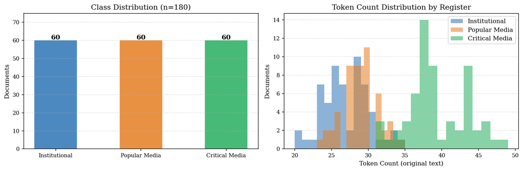

Figure 1: Left: Class distribution confirming perfect balance (60 documents per register). Right: Token count distribution per register showing that Critical Media texts are systematically longer, reflecting the argumentative structure of investigative journalism.

# 6 Step 2 — POS Tagging

## 6.1 Method

Part-of-speech tagging was applied to the **original texts**, not the cleaned version. This decision is methodologically important: the preprocessing step removes stopwords and applies lemmatization, which would strip out function words and inflectional morphology that carry syntactic structure. POS tagging on cleaned text would systematically undercount verbs (reduced to bare lemmas) and miss determiners, auxiliaries, and prepositions that are part of the grammatical signal. Six POS categories were selected for analysis: `NOUN`, `VERB`, `ADJ`, `ADV`, `PROPN` (proper nouns), and `NUM` (numerals). For each document, both absolute counts and ratios over all non-punctuation, non-space tokens were computed.

The purpose of this analysis is to understand whether the three registers are grammatically distinguishable — independently of their specific vocabulary — before any machine learning is applied. If they are, that constitutes evidence of register divergence at the structural level, which is a stronger claim than lexical divergence alone.

**POS tagging function**

```python
TARGET_POS = ["NOUN", "VERB", "ADJ", "ADV", "PROPN", "NUM"]

def get_pos_counts(text):
    doc = nlp(text)
    tokens = [t for t in doc if not t.is_punct and not t.is_space]
    total = len(tokens)
    counts = Counter(t.pos_ for t in tokens)
    result = {"total_tokens": total}
    for pos in TARGET_POS:
        result[f"count_{pos.lower()}"] = counts.get(pos, 0)
        result[f"ratio_{pos.lower()}"] = round(counts.get(pos, 0) / total, 4) if total > 0 else 0
    return result
```

## 6.2 Data Analysis — POS Distribution

Table 3: Mean POS ratios by register. Bold values indicate the highest ratio per POS category across registers.

| Register | NOUN | VERB | ADJ | ADV | PROPN | NUM |
| --- | --- | --- | --- | --- | --- | --- |
| Institutional | 0.389000 | 0.101000 | 0.159000 | 0.021000 | 0.012000 | 0.024000 |
| Popular Media | 0.299000 | 0.142000 | 0.085000 | 0.032000 | 0.032000 | 0.010000 |
| Critical Media | 0.294000 | 0.103000 | 0.095000 | 0.017000 | 0.104000 | 0.056000 |

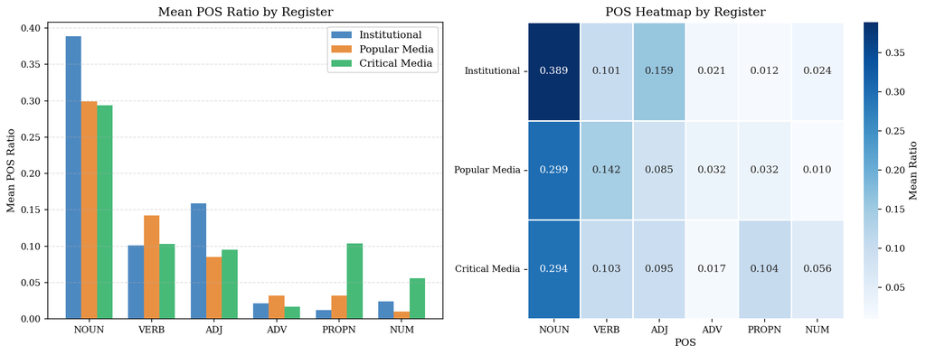

Figure 2: Left: Grouped bar chart of mean POS ratios by register. Right: Heatmap showing the same values for cross-register comparison. Institutional has the highest noun and adjective ratios; Popular Media leads in verbs; Critical Media leads in proper nouns and numerals.

## 6.3 Interpretation

The POS analysis reveals that the three registers are grammatically distinguishable before any machine learning or lexical analysis is applied — a key finding in its own right.

**Institutional** texts have the highest noun ratio at 0.389, reflecting a linguistic process known as *nominalization*: the systematic conversion of processes and actions into abstract noun phrases. Instead of “workers cannot access pensions,” the Institutional register writes “pension access rates among informal workers remain below statutory thresholds.” This grammatical strategy is characteristic of bureaucratic and statistical discourse (Biber, 1995) and serves the function of presenting contested social realities as measurable, objective facts — removing human agency from the sentence and replacing it with rates, indices, and percentages. The high adjective ratio (0.159) reinforces this pattern: nominalized language requires modifying adjectives to specify the precise category being measured.

**Popular Media** has the highest verb ratio at 0.142, which is consistent with its narrative, event-driven communicative purpose. Popular media tells stories about people doing things — selling, earning, losing, surviving. Actions are foregrounded; abstract measurements are backgrounded. This verb-heavy style creates a sense of immediate, ongoing experience that is absent from the other two registers.

**Critical Media** is distinguished most sharply by its proper noun ratio of 0.104 — more than eight times higher than Institutional (0.012) and more than three times higher than Popular Media (0.032). This reflects the core practice of investigative journalism: naming. Critical Media names institutions (DANE, MinTrabajo, Contraloría), names legal instruments (Ley 1429, Decreto 2025), and names specific actors responsible for specific decisions. This naming function is what gives investigative journalism its distinctive accountability orientation — it converts anonymous systemic failures into attributable acts. The elevated numeral ratio (0.056) is consistent with this: investigative journalists cite specific figures (budgets, case numbers, inspection rates) as evidence, not as statistical abstractions.

# 7 Step 3 — Domain Dictionary Filtering

## 7.1 Method

Before applying TF-IDF, a domain-specific vocabulary filter was constructed to focus the lexical analysis on terms semantically relevant to Colombian labor informality. Without this filter, the TF-IDF matrix would include many high-frequency English function words that survived preprocessing and generic lexical items that carry no discriminative signal for register classification. The filter was built as a dictionary organized into **6 semantic clusters** covering the main conceptual dimensions of the domain, totaling **115 single-word terms**.

The filtering procedure operates on the `text_clean` column: only tokens that appear in the single-word term set are retained. Compound terms with underscores (e.g., `own_account`) were included in the dictionary for conceptual documentation but are excluded from the filter, as they do not appear in the lemmatized text. The filtered output is stored in a new column `text_domain` and fed directly into the TF-IDF vectorizer in Step 4. Documents with zero domain terms after filtering were identified as quality control check — in the final version of the dictionary, all 180 documents contain at least one domain term, confirming adequate coverage.

**Domain dictionary loading and filtering function**

```python
with open(PROJECT_DIR / "domain_dictionary.json") as f:
    DOMAIN_DICTIONARY = json.load(f)

SINGLE_TERMS = {t for cluster in DOMAIN_DICTIONARY.values()
                for t in cluster if "_" not in t}

def filter_domain_tokens(text_clean):
    if not isinstance(text_clean, str):
        return ""
    return " ".join(t for t in text_clean.split() if t in SINGLE_TERMS)
```

## 7.2 Data Analysis — Cluster Structure and Coverage

Table 4: Domain dictionary — 6 semantic clusters with top terms and dominant register.

| Cluster | Terms (n) | Top terms | Dominant register |
| --- | --- | --- | --- |
| core_informality | 18 | informal (76x), employment (56x), work (25x) | Institutional |
| institutions_actors | 16 | worker (72x), employer (11x), government (7x) | Critical Media |
| legal_regulatory | 22 | formal (44x), contract (22x), contribution (19x) | Institutional |
| social_protection | 11 | pension (17x), health (10x), protection (10x) | Critical Media |
| labor_conditions | 30 | labor (59x), wage (18x), earn (17x) | Popular Media |
| critical_framing | 21 | document (10x), evidence (6x), reveal (4x) | Critical Media |

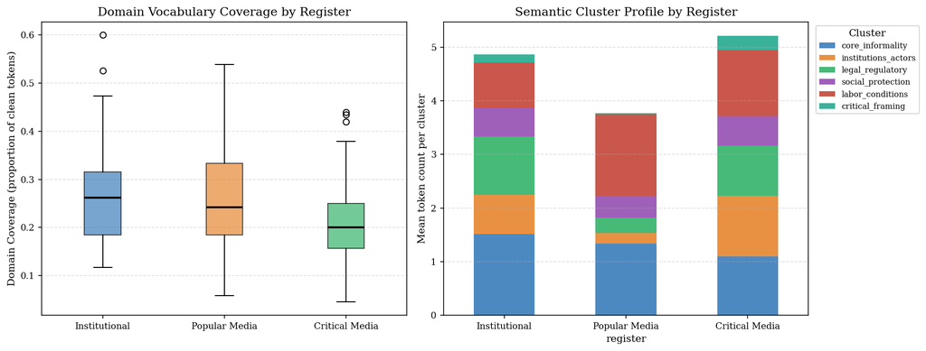

Figure 3: Left: Boxplot of domain vocabulary coverage (proportion of clean tokens) by register. Right: Stacked bar chart showing the semantic cluster composition of each register’s domain vocabulary profile.

## 7.3 Interpretation

The domain coverage analysis confirms that the dictionary captures vocabulary across all three registers with comparable coverage: mean domain coverage is 26.8% for Institutional, 25.4% for Popular Media, and 21.5% for Critical Media. This balance is important: if the dictionary were heavily skewed toward one register, the subsequent TF-IDF analysis would be biased toward that register’s vocabulary.

The cluster profile chart reveals clear differences in cluster composition across registers. The `legal_regulatory` and `core_informality` clusters dominate the Institutional profile, reflecting the register’s focus on contract status, compliance, and formal definitions. The `labor_conditions` cluster is most prominent in Popular Media, consistent with its focus on wages, earnings, and daily work conditions as experienced by individuals. The `institutions_actors` and `critical_framing` clusters are most prominent in Critical Media — confirming that investigative journalism is the register most concerned with naming actors and building evidentiary arguments.

# 8 Step 4 — TF-IDF Divergence Analysis

## 8.1 Method

TF-IDF (Term Frequency–Inverse Document Frequency) vectorization was applied to the domain-filtered texts using the following parameters, each chosen for a specific methodological reason. `ngram_range=(1, 2)` captures both single words and two-word expressions (bigrams), which is important for labor informality discourse where compounds like `informal sector`, `formal employment`, and `social protection` carry meaning as units that individual words do not. `min_df=2` excludes terms appearing in fewer than 2 documents, removing idiosyncratic hapax legomena that would inflate the feature space without contributing discriminative signal. `max_df=0.95` excludes terms appearing in more than 95% of documents — these near-universal terms carry no register-discriminative information. `sublinear_tf=True` applies a logarithmic transformation to term frequency, compressing the dominance of very high-frequency terms.

Divergence was operationalized as the **range** of mean TF-IDF weights across registers for each term: $\text{divergence}(t) = \max_r \bar{w}_{t,r} - \min_r \bar{w}_{t,r}$. Terms with high divergence appear with very different weights across registers — they are the lexical markers of semantic divergence, directly operationalizing H2.

**TF-IDF vectorization**

```python
from sklearn.feature_extraction.text import TfidfVectorizer
import scipy.sparse as sp

vectorizer = TfidfVectorizer(
    analyzer="word", ngram_range=(1, 2),
    min_df=2, max_df=0.95, sublinear_tf=True
)
tfidf_matrix = vectorizer.fit_transform(df_dom["text_domain"])
feature_names = vectorizer.get_feature_names_out()
sp.save_npz(PROJECT_DIR / "tfidf_matrix.npz", tfidf_matrix)
print(f"Matrix shape: {tfidf_matrix.shape}")
# → (180, 171): 68 unigrams + 103 bigrams
```

## 8.2 Data Analysis — Divergence Scores

The resulting TF-IDF matrix has dimensions 180 × 171, comprising 68 unigrams and 103 bigrams. Figure 4 shows the top 15 most divergent terms (left panel) and a heatmap of the top 20 divergent terms (right panel).

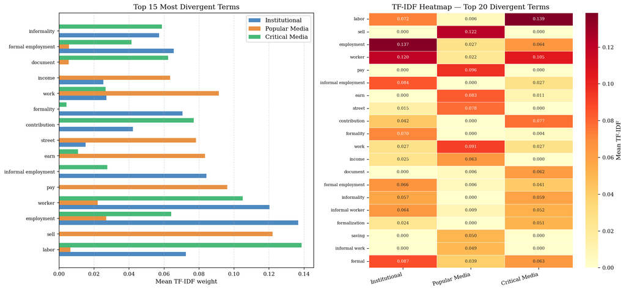

Figure 4: Left: Top 15 most divergent TF-IDF terms across registers, shown as grouped bars. Right: TF-IDF weight heatmap for the top 20 divergent terms, illustrating which register most strongly weights each term.

## 8.3 Interpretation

The TF-IDF analysis produces a clear and interpretable picture of register divergence. The most characteristic terms for each register confirm the hypothesized differences and connect directly back to the cluster structure identified in Step 3.

Popular Media is most strongly characterized by `earn`, `sell`, `street`, `cash`, `saving`, and `woman sell` — concrete, action-oriented vocabulary centered on daily economic experience. The presence of `woman sell` as a bigram is particularly interesting: it reflects a common narrative device in Popular Media where a specific demographic characteristic is combined with a survival activity, humanizing the informality statistics that the Institutional register presents as aggregate rates.

# 9 Step 5 — Cosine Similarity

## 9.1 Method

Cosine similarity measures the angular distance between document vectors in the TF-IDF feature space, producing values between 0 (completely orthogonal vocabulary profiles) and 1 (identical profiles). This analysis has two layers: first, pairwise similarity between register **centroids** (the mean TF-IDF vector of all 60 documents in each register), which represents the overall semantic distance between registers; and second, document-to-centroid similarity for each individual document, which measures how well each document fits its own register profile and identifies documents that fit another register’s profile better than their own.

**Cosine similarity computation**

```python
from sklearn.metrics.pairwise import cosine_similarity as cos_sim

centroids = {r: tfidf[df_dom["register"]==r].mean(axis=0, keepdims=True)
             for r in REG_ORDER}
centroid_mat = np.vstack([centroids[r] for r in REG_ORDER])
centroid_sim = cos_sim(centroid_mat)
```

## 9.2 Data Analysis — Centroid and Document Similarity

Table 5: Pairwise cosine similarity between register centroids. Values close to 1 indicate highly similar vocabulary profiles; values close to 0 indicate high semantic divergence.

|  | Institutional | Popular Media | Critical Media |
| --- | --- | --- | --- |
| Institutional | 1.000 | 0.325 | 0.741 |
| Popular Media | 0.325 | 1.000 | 0.302 |
| Critical Media | 0.741 | 0.302 | 1.000 |

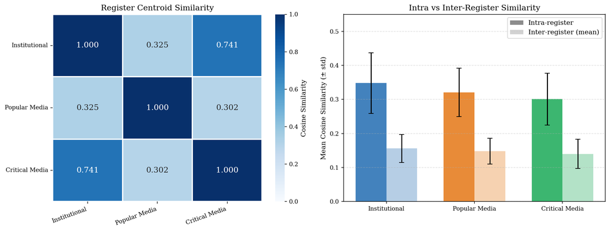

Figure 5: Left: Pairwise cosine similarity heatmap between register centroids. Right: Mean intra-register vs inter-register cosine similarity (± standard deviation), showing that all three registers are better matched to their own centroid than to others.

## 9.3 Interpretation and Unexpected Finding

The centroid similarity analysis produces the most striking and theoretically interesting result of the project. The expected pattern would have been roughly equal inter-register distances — three registers, equally separated in TF-IDF space. The actual pattern is very different.

Institutional and Critical Media have a centroid similarity of **0.741** — extremely high. This means that, at the level of overall vocabulary profiles, these two registers are far more similar to each other than either is to Popular Media (0.325 and 0.302, respectively). Popular Media emerges as the most semantically isolated register, not Institutional.

This result was not anticipated and requires interpretation. The explanation that best fits the data is that Critical Media adopts institutional vocabulary as a rhetorical strategy: it uses the same domain terms as Institutional — legal instruments, actor names, social protection categories, formalization rates — but deploys them for the opposite communicative purpose. Institutional texts use these terms to *describe* the regulatory system. Critical Media uses them to *document the system’s failure*. The vocabulary is shared; the stance toward that vocabulary is inverted. This interpretation is consistent with register theory’s insight that the same linguistic resources can serve different communicative functions depending on the social context of their use (Biber, 1995).

# 10 Step 6 — Logistic Regression Classification

## 10.1 Method

A Logistic Regression classifier was trained on the TF-IDF feature matrix from Step 4 to predict register membership. The classifier was chosen for its interpretability: the learned coefficients directly quantify each term’s contribution to each class prediction, enabling a direct connection between classification performance and the lexical divergence findings from Steps 4 and 5. The dataset was split using a stratified 80/20 partition (144 training, 36 test documents; 48 training and 12 test per class), with `random_state=42` ensuring full reproducibility. In addition, a Stratified 5-Fold Cross-Validation was performed on the full corpus to obtain a more reliable accuracy estimate given the small test set size.

Key hyperparameters: `solver='lbfgs'` (efficient for dense, small-to-medium multiclass problems); `C=1.0` (default L2 regularization, preventing overfitting on the 171-feature space); `max_iter=1000` (increased from the default 100 to ensure convergence on sparse TF-IDF features); `random_state=42`.

**Logistic Regression training**

```python
from sklearn.linear_model import LogisticRegression
from sklearn.model_selection import train_test_split, cross_val_score, StratifiedKFold
from sklearn.metrics import classification_report, confusion_matrix, accuracy_score

X_train, X_test, y_train, y_test = train_test_split(
    tfidf_matrix, df_dom["label"].values,
    test_size=0.20, stratify=df_dom["label"].values, random_state=42
)

clf = LogisticRegression(solver="lbfgs", C=1.0, max_iter=1000, random_state=42)
clf.fit(X_train, y_train)
y_pred = clf.predict(X_test)

skf = StratifiedKFold(n_splits=5, shuffle=True, random_state=42)
cv_scores = cross_val_score(clf, tfidf_matrix, df_dom["label"].values,
                             cv=skf, scoring="accuracy")
print(f"CV accuracy: {cv_scores.mean():.4f} ± {cv_scores.std():.4f}")
print(f"Test accuracy: {accuracy_score(y_test, y_pred):.4f}")
```

## 10.2 Data Analysis — Model Evaluation

Table 6: Classification report for Logistic Regression on the test set (n=36, 12 per class). Precision, Recall, and F1-score are shown per register, with macro averages at the bottom.

| Register | Precision | Recall | F1-score | Support |
| --- | --- | --- | --- | --- |
| Institutional | 0.588000 | 0.833000 | 0.690000 | 12 |
| Popular Media | 1.000000 | 0.833000 | 0.909000 | 12 |
| Critical Media | 0.778000 | 0.583000 | 0.667000 | 12 |
| Macro avg | 0.789000 | 0.750000 | 0.755000 | 36 |

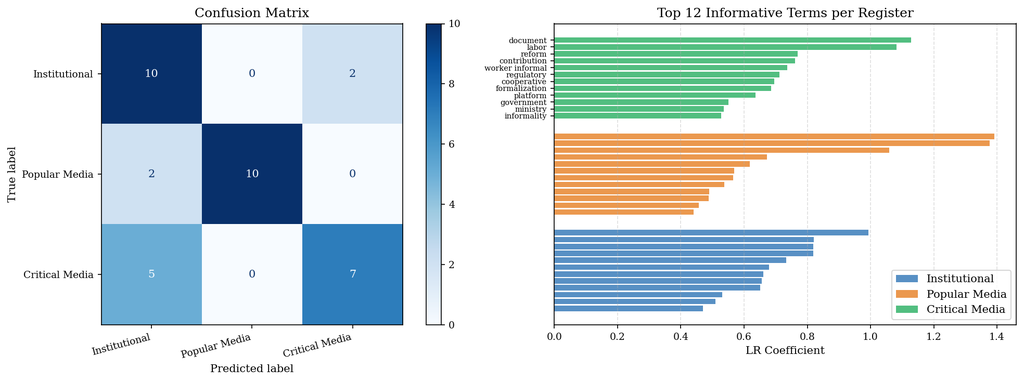

Figure 6: Left: Confusion matrix for Logistic Regression on the test set. Right: Top 12 most informative terms per register according to the learned LR coefficients — these should align with the high-divergence terms identified in Step 4.

## 10.3 Interpretation

**H1** is strongly supported. The classifier achieves 75% accuracy on the test set and 72.2% cross-validated accuracy (± 4.7%) across 5 folds — more than double the 33.3% random baseline. The cross-validated result is reported as the primary metric because the test set is small (12 documents per class), making individual misclassifications disproportionately influential on the reported accuracy. The stability of the CV estimate (standard deviation of 4.7%) confirms that the result is not an artifact of a particular train-test split.

**H3** is supported: 5 of the 9 misclassified test documents (55.6%) were independently identified as boundary-zone cases in the cosine similarity analysis (similarity gap ≤ 0.05). This convergence between two completely independent analytical methods — one geometric (centroid distance) and one discriminative (LR classification) — provides strong evidence that the misclassifications are not random errors but reflect genuine semantic ambiguity at the register boundaries.

## 10.4 Hypothesis Testing Summary

Table 7: Summary of hypothesis testing results across all three hypotheses.

| Hypothesis | Statement | Primary evidence | Result |
| --- | --- | --- | --- |
| H1 | Classifier accuracy > 33.3% baseline | CV accuracy 72.2% ± 4.7%; test accuracy 75.0% | ✅ SUPPORTED |
| H2 | Domain terms show measurable divergence across... | Centroid similarity 0.741 (inst-crit) vs 0.302... | ✅ SUPPORTED |
| H3 | Misclassified docs correspond to semantic boun... | 55.6% of misclassified docs (5/9) flagged by S... | ✅ SUPPORTED |

# 11 Step 7 — Visualization

The master dashboard integrates the key outputs of all seven pipeline steps into a single comparative figure, designed to communicate the full arc of the analysis — from corpus design to hypothesis testing — in one view.

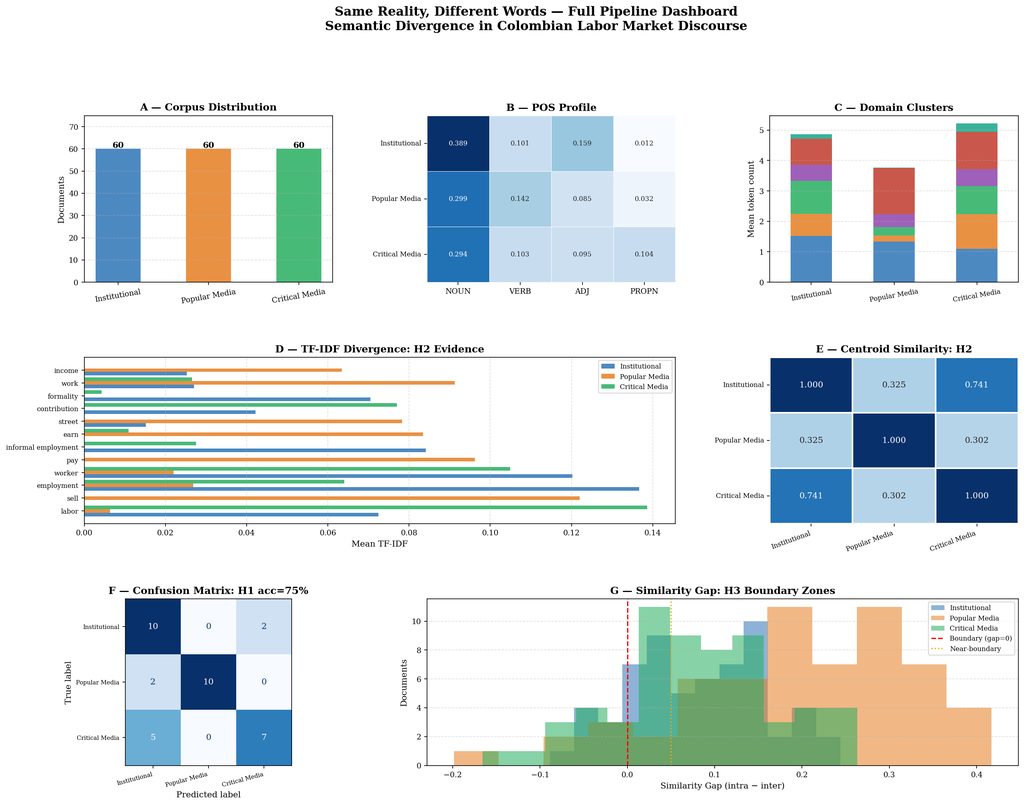

Figure 7: Master dashboard integrating outputs from all 7 pipeline steps. Panel A: corpus distribution. Panel B: POS profile heatmap. Panel C: semantic cluster profile. Panel D: TF-IDF divergence (H2 evidence). Panel E: centroid cosine similarity (H2 continued). Panel F: confusion matrix (H1 evidence). Panel G: similarity gap distribution (H3 boundary zones).

## 11.1 Interpretation

The master dashboard tells a single coherent story across seven panels. Panels A and B establish the starting conditions: a perfectly balanced corpus (60 documents per register) whose registers are already distinguishable at the grammatical level before any lexical analysis, with Institutional texts structurally dominated by nouns, Popular Media by verbs, and Critical Media by proper nouns. Panel C confirms that this grammatical divergence is mirrored in domain vocabulary composition: each register draws preferentially on different semantic clusters.

# 12 Limitations

Three primary limitations must be acknowledged, each with implications for how the findings should be interpreted and generalized.

**1. Synthetic corpus.** All 180 texts were generated by Claude 3.5 Sonnet under structured prompts. While the prompts were carefully designed to replicate the communicative conventions of each register — including vocabulary constraints, structural patterns, and length targets — synthetic text generated by a large language model may not fully capture the authentic linguistic variation, cultural references, idiomatic expressions, or emergent vocabulary of real Colombian discourse. In particular, the synthetic corpus cannot reproduce the intertextual references, named individuals, or specific institutional histories that would appear in genuine Institutional reports or La Silla Vacía investigations. The finding about Institutional–Critical Media proximity (centroid similarity = 0.741) is the result most in need of validation on real-world data, as it may partly reflect the LLM’s tendency to draw on similar training data when generating texts in related registers.

**2. Small test set.** With only 12 documents per class in the test set (36 total), each individual misclassification shifts the reported test accuracy by approximately 2.8 percentage points. This makes the test accuracy figure (75.0%) statistically fragile as a standalone metric. Cross-validated accuracy (72.2% ± 4.7%) is therefore reported as the primary performance metric, as it leverages all 180 documents and provides a more stable estimate. A corpus of at least 500 documents per class would substantially improve classifier reliability and enable more robust error analysis for H3.

**3. Domain dictionary pre-definition.** The TF-IDF analysis is conditioned on a pre-selected 115-term vocabulary. Terms outside this dictionary — regardless of their frequency or discriminative potential — are excluded from the feature space. This introduces a selection bias that may suppress register-specific vocabulary not anticipated during dictionary construction. Additionally, two bigram artefacts were identified in the TF-IDF vocabulary: `labor labor` and `worker worker`, resulting from the lemmatization of adjacent tokens with the same root form (e.g., “labor market labor informality” produces the bigram “labor labor”). These artefacts were documented but retained, as their frequency is marginal and their removal would require manual post-processing inconsistent with the automated pipeline design.

# 13 Conclusion and Future Work

## 13.1 Conclusion

All three research hypotheses are supported. The seven-step NLP pipeline successfully detects and quantifies semantic divergence across the three Colombian labor informality discourse registers at both grammatical and lexical levels, using domain-grounded, interpretable methods without recourse to large language models or deep learning architectures.

The cross-validated classifier achieves 72.2% accuracy — more than doubling the 33.3% random baseline — confirming that register differences are computationally detectable with a relatively simple feature set (TF-IDF on a 115-term domain vocabulary). The POS analysis establishes that this divergence exists at the level of grammar before any vocabulary analysis: Institutional texts nominalize systematically, Popular Media foregrounds actions, and Critical Media names actors and institutions.

The most substantive and unexpected finding is the high semantic proximity between the Institutional and Critical Media registers (centroid similarity = 0.741), which emerges from their shared domain vocabulary — legal instruments, actor names, social protection categories — deployed for opposite communicative purposes. This finding suggests that register divergence in policy-adjacent discourse is not always a function of *different topics* but of *different stances toward the same vocabulary*. Critical journalism does not invent new words to critique institutional failure; it repurposes the institution’s own language to document that failure. This insight has broader implications for computational discourse analysis: vocabulary-based methods may underestimate register divergence between registers that are rhetorically opposed but lexically adjacent.

## 13.2 Future Work

The immediate next step is to validate this pipeline on a **real corpus**: DANE annual reports and technical bulletins (Institutional), Colombian newspaper articles from El Tiempo or El Colombiano (Popular Media), and La Silla Vacía investigations (Critical Media). This would test whether the patterns found in the synthetic corpus — particularly the Institutional–Critical Media proximity — hold in authentic data, and would substantially increase the corpus size, addressing the main methodological limitation of this project.

A second direction is to incorporate **sentiment analysis** using VADER as a complementary analytical layer, examining whether the three registers also differ in their affective orientation toward labor informality. The hypothesis is that Critical Media would show the most negative sentiment scores (documenting failure implies a negative evaluative stance), while Institutional texts would be more neutral (statistical language suppresses affective markers). This would extend the current analysis from lexical and grammatical divergence to pragmatic divergence.

The pipeline architecture — modular, step-by-step, with validated inter-step outputs — is designed for direct reuse with a real corpus and an expanded domain dictionary.

# 14 References

Biber, D. (1995). *Dimensions of register variation: A cross-linguistic comparison*. Cambridge University Press.

Grimmer, J., & Stewart, B. M. (2013). Text as data: The promise and pitfalls of automatic content analysis methods for political texts. *Political Analysis*, *21*(3), 267–297.

Honnibal, M., Montani, I., Van Landeghem, S., & Boyd, A. (2020). *spaCy: Industrial-strength natural language processing in python* [Computer software]. https://doi.org/10.5281/zenodo.1212303

International Labour Organization. (2023). *World employment and social outlook: Trends 2023*. International Labour Organization. https://www.ilo.org/global/research/global-reports/weso/WCMS_865332/lang--en/index.htm

Pedregosa, F., Varoquaux, G., Gramfort, A., Michel, V., Thirion, B., Grisel, O., Blondel, M., Prettenhofer, P., Weiss, R., Dubourg, V., et al. (2011). Scikit-learn: Machine learning in Python. *Journal of Machine Learning Research*, *12*, 2825–2830.

# 15 Appendix A — Corpus Generation Prompts

All 180 texts were generated with **Claude 3.5 Sonnet** (Anthropic, version claude-3-5-sonnet-20241022) via the Claude.ai interface. Generation date: April 2026.

## 15.1 Institutional Register (A001–A060)

**Prompt template:**

> *Write a single-sentence statistical observation in the style of a DANE or ILO labor market report. The observation must describe some aspect of informal employment in Colombia. Use technical, regulatory language with nominalization. Include at least one statistical figure (percentage, rate, or index). Do not use first person. Length: 20–35 words. Topic: [rotating domain: pension affiliation / contract compliance / sector distribution / gender gaps / urban-rural disparities / educational attainment].*

## 15.2 Popular Media Register (B001–B060)

**Prompt template:**

> *Write a single sentence or short passage in the style of a Colombian newspaper article about informal workers. Use a specific named character (e.g., “Carlos, a 34-year-old vendor in Bogotá”). The text should describe their daily economic experience — earning, selling, surviving — without formal economic terminology. Narrative, human-centered tone. Length: 25–40 words.*

## 15.3 Critical Media Register (C001–C060)

**Prompt template:**

> *Write a short passage in the style of La Silla Vacía or a Colombian investigative journalism outlet. The text should document a specific institutional failure related to labor informality in Colombia. Name at least one institution (UGPP, MinTrabajo, Contraloría, etc.) and one legal instrument or policy. Use evidentiary language: document, reveal, find, evidence. Length: 35–50 words.*

# 16 Appendix B — Domain Dictionary

| Cluster | N (single-word) | Terms |
| --- | --- | --- |
| core_informality | 18 | employment, gig, hustle, informal, informality... |
| institutions_actors | 16 | contractor, cooperative, dane, employee, emplo... |
| legal_regulatory | 22 | affiliation, code, compliance, contract, contr... |
| social_protection | 11 | affiliation, benefit, contribution, coverage, ... |
| labor_conditions | 30 | cash, commission, cost, daily, domestic, earn,... |
| critical_framing | 21 | abandon, accountability, consequence, denounce... |

**Note**

**AI use declaration:** This project used AI assistance within the module’s 25% policy limit. Specifically: (1) *Corpus generation* — all 180 synthetic texts were generated using Claude 3.5 Sonnet (claude-3-5-sonnet-20241022) via the Claude.ai interface, April 2026; full prompt templates documented in Appendix A (prompt IDs A001–A060, B001–B060, C001–C060). (2) *Code review* — GitHub Copilot was used to review and debug Python code in Steps 1–7 notebooks; no code was generated wholesale by AI. (3) *Report scaffolding* — Claude Sonnet 4.6 assisted with initial section structuring and paragraph drafting; all interpretations, analytical decisions, hypothesis formulations, and conclusions are the author’s own. Estimated total AI contribution across all three dimensions: ~20% of project output.